# Machine Learning Project

Mayank

March 20, 2016

```r
library(caret)
training=read.csv("C:/Users/Lenovo/Downloads/pml-training.csv",header=T)
testing=read.csv("C:/Users/Lenovo/Downloads/pml-testing.csv",header=T)
dim(training)
```

```
## [1] 19622   160
```

```r
dim(testing)
```

```
## [1]  20 160
```

training and testing contains the training and testing dataset respectively,as provided for the assignment.

Our first job includes finding all the NA’s in the dataset

```r
d=which(is.na(training),arr.ind = T)
d=as.data.frame(d)
un=unique(d[[2]])
un
```

```
##  [1]  18  19  21  22  24  25  27  28  29  30  31  32  33  34  35  36  50
## [18]  51  52  53  54  55  56  57  58  59  75  76  77  78  79  80  81  82
## [35]  83  93  94  96  97  99 100 103 104 105 106 107 108 109 110 111 112
## [52] 131 132 134 135 137 138 141 142 143 144 145 146 147 148 149 150
```

```r
#These Columns only have  NA's in them, so it is better to remove them before training the model as they are of no use.
train=training[-un]
dim(train)
```

```
## [1] 19622    93
```

```r
#removing unwanted variables
train=train[-c(1:7)]
dim(train)
```

```
## [1] 19622    86
```

Now the next step is to find highly correlated variables in the dataset

```r
#We can only find the correlation among numeric variables.
co=cor(train[sapply(train,is.numeric)])
dim(co)
```

```
## [1] 52 52
```

```r
remove=findCorrelation(co,cutoff = 0.9)#Finding variables with correlation greater than 0.9 and removing them.
co=as.data.frame(co)
train2=train[names(co)]
train2=train2[-remove]
train2=cbind(train2,training[160])# Including the outcome variable.
dim(train2)
```

```
## [1] 19622    46
```

Now we have comparitively small number of variables to include in the training model.

## Cross Validation

```r
intrain=createDataPartition(train2$classe,p = 0.8,list=F)
model_training=train2[intrain,]
model_testing=train2[-intrain,]
```

**Rpart Package in caret**

```r
library(rpart)
model1=train(classe~.,data=model_training,method="rpart")
library(rattle)
```

[figure not shown]

```r
fancyRpartPlot(model1$finalModel)#A pretty plot
```

```r
pre1=predict(model1,newdata=model_testing)#Cross Validating
sum(diag(table(pre1,model_testing$classe)))/sum(as.numeric(table(pre1,model_testing$classe)))#Accuracy
```

```
## [1] 0.4894214
```

This shows a 50% percent missclassification error on the vlaidation dataset.Therefore rpart does not give a good fit.

**TREE**

```r
library(tree)
model2=tree(classe~.,data=model_training)
model2
```

```
## node), split, n, deviance, yval, (yprob)
##       * denotes terminal node
##
##   1) root 15699 49850.00 A ( 0.2843493 0.1935155 0.1744060 0.1638958 0.1838334 )
##     2) pitch_forearm < -33.95 1279    86.87 A ( 0.9945270 0.0054730 0.0000000 0.0000000 0.0000000 ) *
##     3) pitch_forearm > -33.95 14420 46330.00 A ( 0.2213592 0.2101942 0.1898752 0.1784327 0.2001387 )
##       6) magnet_belt_y < 554.5 1158  1173.00 E ( 0.0008636 0.0025907 0.0000000 0.1873921 0.8091537 )
##        12) accel_forearm_z < 120.5 902     0.00 E ( 0.0000000 0.0000000 0.0000000 0.0000000 1.0000000 ) *
##        13) accel_forearm_z > 120.5 256   248.80 D ( 0.0039062 0.0117188 0.0000000 0.8476562 0.1367188 ) *
##       7) magnet_belt_y > 554.5 13262 42290.00 A ( 0.2406123 0.2283215 0.2064545 0.1776504 0.1469612 )
##        14) magnet_dumbbell_y < 439.5 11085 34850.00 A ( 0.2824538 0.1806044 0.2394226 0.1714028 0.1261164 )
##          28) roll_forearm < 123.5 6996 20740.00 A ( 0.4032304 0.1812464 0.1795312 0.1442253 0.0917667 )
##            56) magnet_dumbbell_z < -27.5 2407  4832.00 A ( 0.6506024 0.2147902 0.0124636 0.0731201 0.0490237 )
##             112) accel_dumbbell_y < -51.5 259   529.60 B ( 0.0270270 0.5830116 0.1003861 0.0038610 0.2857143 ) *
##             113) accel_dumbbell_y > -51.5 2148  3565.00 A ( 0.7257914 0.1703911 0.0018622 0.0814711 0.0204842 )
##               226) roll_forearm < -135.5 307   772.20 D ( 0.1433225 0.3322476 0.0000000 0.4104235 0.1140065 ) *
##               227) roll_forearm > -135.5 1841  2116.00 A ( 0.8229223 0.1434003 0.0021727 0.0266160 0.0048886 ) *
##            57) magnet_dumbbell_z > -27.5 4589 14330.00 A ( 0.2734801 0.1636522 0.2671606 0.1815210 0.1141861 )
##             114) pitch_belt < -42.45 1100  2430.00 A ( 0.5045455 0.3609091 0.0754545 0.0472727 0.0118182 )
##               228) yaw_belt < 169.5 577  1226.00 B ( 0.1577123 0.6395147 0.1438475 0.0363951 0.0225303 ) *
##               229) yaw_belt > 169.5 523   450.20 A ( 0.8871893 0.0535373 0.0000000 0.0592734 0.0000000 ) *
##             115) pitch_belt > -42.45 3489 10720.00 C ( 0.2006306 0.1014617 0.3276010 0.2238464 0.1464603 )
##               230) accel_forearm_x < -70.5 1777  4732.00 C ( 0.0360158 0.0613393 0.4040518 0.3162634 0.1823298 ) *
##               231) accel_forearm_x > -70.5 1712  5125.00 A ( 0.3714953 0.1431075 0.2482477 0.1279206 0.1092290 )
##                 462) accel_dumbbell_z < 32.5 1332  3521.00 A ( 0.4286787 0.0975976 0.3190691 0.1231231 0.0315315 ) *
##                 463) accel_dumbbell_z > 32.5 380   996.50 E ( 0.1710526 0.3026316 0.0000000 0.1447368 0.3815789 ) *
##          29) roll_forearm > 123.5 4089 12390.00 C ( 0.0758132 0.1795060 0.3418929 0.2179017 0.1848863 )
##            58) magnet_dumbbell_z < 284.5 3334  9233.00 C ( 0.0257948 0.1445711 0.4136173 0.2477504 0.1682663 )
##             116) accel_forearm_x < -101.5 1191  2846.00 D ( 0.0503778 0.0545760 0.2468514 0.5591940 0.0890008 )
##               232) magnet_arm_x < 125 361   710.50 C ( 0.0110803 0.1135734 0.6454294 0.2105263 0.0193906 ) *
##               233) magnet_arm_x > 125 830  1614.00 D ( 0.0674699 0.0289157 0.0734940 0.7108434 0.1192771 ) *
##             117) accel_forearm_x > -101.5 2143  5312.00 C ( 0.0121325 0.1945870 0.5062996 0.0746617 0.2123192 ) *
##            59) magnet_dumbbell_z > 284.5 755  2084.00 B ( 0.2966887 0.3337748 0.0251656 0.0860927 0.2582781 )
##             118) accel_dumbbell_z < 45 283   465.90 A ( 0.7597173 0.1060071 0.0636042 0.0671378 0.0035336 ) *
##             119) accel_dumbbell_z > 45 472   977.70 B ( 0.0190678 0.4703390 0.0021186 0.0974576 0.4110169 ) *
##        15) magnet_dumbbell_y > 439.5 2177  5461.00 B ( 0.0275609 0.4712908 0.0385852 0.2094626 0.2531006 )
##          30) pitch_belt < 14.85 1317  2902.00 B ( 0.0455581 0.4624146 0.0637813 0.0151860 0.4130600 ) *
##          31) pitch_belt > 14.85 860  1263.00 D ( 0.0000000 0.4848837 0.0000000 0.5069767 0.0081395 )
##            62) yaw_belt < -2.825 416     0.00 B ( 0.0000000 1.0000000 0.0000000 0.0000000 0.0000000 ) *
##            63) yaw_belt > -2.825 444    86.15 D ( 0.0000000 0.0022523 0.0000000 0.9819820 0.0157658 ) *
```

This shows numerous number of splits in the tree which gives rise to the number of leaves.  
Let’s see a prettier version for the same

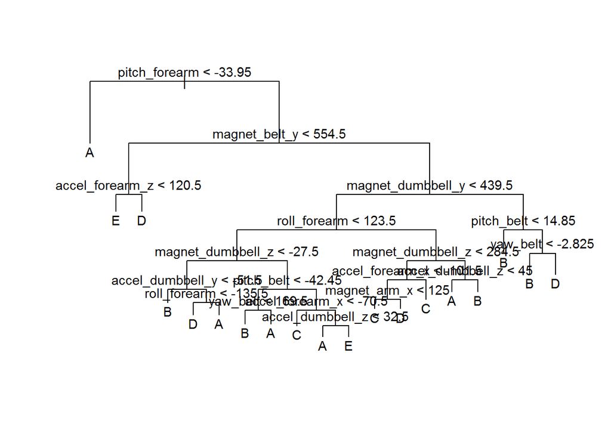

```r
plot(model2)
text(model2,pretty=0,cex=0.9)
```

```r
pre2=predict(model2,newdata=model_testing,type="class")
sum(diag(table(pre2,model_testing$classe)))/sum(as.numeric(table(pre2,model_testing$classe)))
```

```
## [1] 0.6365027
```

But still it’s not good enough to settle, so let’s check for other methods.

**NaiveBayes**

```r
library(e1071)
model3=naiveBayes(classe~.,data=model_training)
pre3=predict(model3,newdata=model_testing)
sum(diag(table(pre3,model_testing$classe)))/sum(as.numeric(table(pre3,model_testing$classe)))
```

```
## [1] 0.5381086
```

0.53 is definitely an improvement over the rpart method but it is way less accurate than tree.

**SVM**

```r
model4=svm(classe~.,data=model_training)
pre4=predict(model4,newdata=model_testing)
sum(diag(table(pre4,model_testing$classe)))/sum(as.numeric(table(pre4,model_testing$classe)))
```

```
## [1] 0.9500382
```

Finally! a good fit.With a missclassification error of 5% SVM can be considered as the best option.

## Conclusion

Considering accuracy as the metric for above models, SVM comes out as the most promising modeling technique for the problem in hand.  
Now lets predict for the test dataset.

```r
predict(model4,testing)
```

```
##  1  2  3  4  5  6  7  8  9 10 11 12 13 14 15 16 17 18 19 20
##  B  A  B  A  A  E  D  B  A  A  B  C  B  A  E  E  A  B  B  B
## Levels: A B C D E
```

These are the classes for the entries in the test dataset.SvM is proved to be the most effective model for training.